# Peer Assessment 1

Francis A. Méndez Mediavilla

December 10, 2014

## Loading and preprocessing the data

The number of steps taken were collected for the period of October 1, 2012 until November 30, 2012.

```r
dat<-read.csv(file="activity.csv", header=T)
head(dat)
```

```
##   steps       date interval
## 1    NA 2012-10-01        0
## 2    NA 2012-10-01        5
## 3    NA 2012-10-01       10
## 4    NA 2012-10-01       15
## 5    NA 2012-10-01       20
## 6    NA 2012-10-01       25
```

```r
tail(dat)
```

```
##       steps       date interval
## 17563    NA 2012-11-30     2330
## 17564    NA 2012-11-30     2335
## 17565    NA 2012-11-30     2340
## 17566    NA 2012-11-30     2345
## 17567    NA 2012-11-30     2350
## 17568    NA 2012-11-30     2355
```

## What is mean total number of steps taken per day?

Compute the total number of steps taken per day. The first step is to aggregate steps per day. `steps` is defined as the number of steps taking in a 5-minute interval.

```r
steps.agg<-aggregate(steps~date,
                     FUN=sum,
                     data=dat)
```

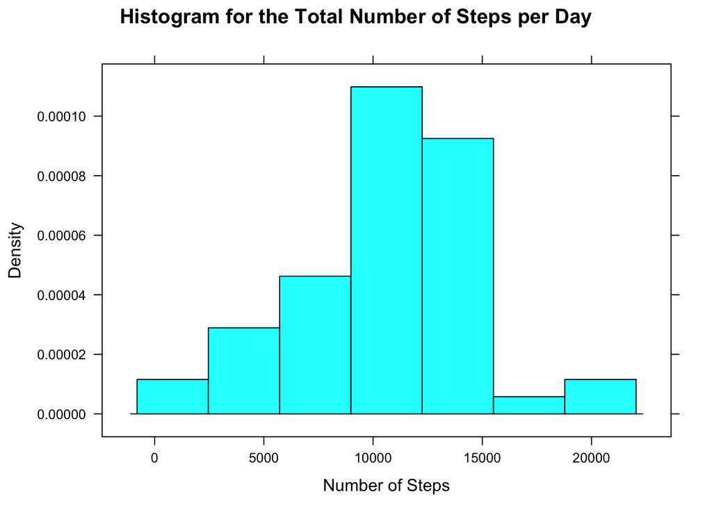

```r
histogram(steps.agg$steps,
          type="density",
          xlab="Number of Steps",
          main="Histogram for the Total Number of Steps per Day")
```

## Calculate and report the mean and median total number of steps taken per day

```r
steps.mean.agg<-mean(steps.agg$steps)
steps.median.agg<-median(steps.agg$steps)
```

The mean total number of steps per day is 10766 and the median number of total steps per day is 10765.

## What is the average daily activity pattern?

### Imputation of missing values.

```r
num.missing<-sum(is.na(dat$steps))
```

The total number of missing values in the dataset is 2304.

### Impute the missing values

```r
# Compute the mean number of steps by interval
steps.mean<-aggregate(steps~interval,
                     FUN=mean,
                     data=dat,
                     simplify=T)
# Create variable "dat$steps.imp2".  Contains imputed values.
dat$steps.imp2<-numeric(length(dat$steps))
for (j in 1:length(steps.mean)){
        for (i in 1:length(dat$steps)){
                if(dat$interval[i]==steps.mean$interval[j]){
                        dat$steps.imp2[i]<-steps.mean$steps[j]
                }
        }
}
# Replaces NAs with imputed values
for (i in 1:length(dat$steps)){
        if(is.na(dat$steps[i])){
                dat$steps[i]<-dat$steps.imp2[i]
        }
}
# Deletes the variable containing imputed values
dat$steps.imp2<-NULL
```

## What is the average daily activity pattern?

A time series depicts the behavior of the average daily pattern for the number of steps by 5-minute intervals.

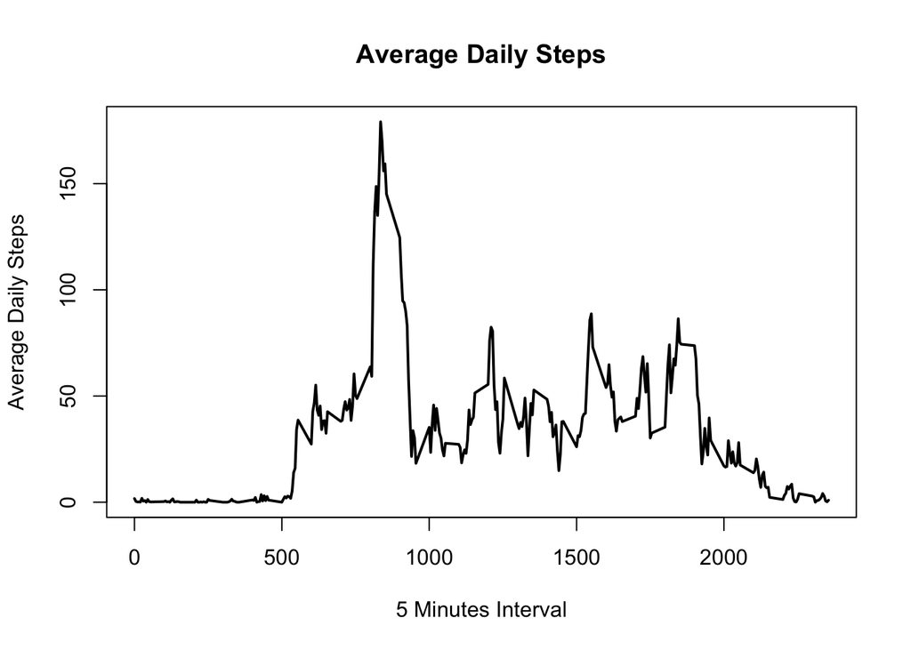

```r
# Recompute the means with the imputations in place
steps.mean<-aggregate(steps~interval,
                     FUN=mean,
                     data=dat,
                     simplify=T)

plot(steps.mean$interval,
     steps.mean$steps,
     type="l", lwd=2,
     xlab="5 Minutes Interval",
     ylab="Average Daily Steps",
     main="Average Daily Steps")
```

### Which 5-minute interval, on average across all the days in the dataset, contains the maximum number of steps?

```r
max.interval<-steps.mean[which.max(steps.mean$steps),]$interval
max.steps<-steps.mean[which.max(steps.mean$steps),]$steps
```

The maximum number of average daily steps (i.e., 179.1311) occurs at interval 835.

## Are there differences in activity patterns between weekdays and weekends?

```r
# If the day is a weekday, variable WeekDay is set to TRUE
dat$WeekDay<-(weekdays(as.POSIXct(strptime(dat$date, "%Y-%m-%d")))!="Sunday" & weekdays(as.POSIXct(strptime(dat$date, "%Y-%m-%d")))!="Saturday")

weekday.steps.mean<-aggregate(steps[dat$WeekDay==TRUE]~interval[dat$WeekDay==TRUE],
                     FUN=mean,
                     data=dat,
                     simplify=T)

weekend.steps.mean<-aggregate(steps[dat$WeekDay==FALSE]~interval[dat$WeekDay==FALSE],
                     FUN=mean,
                     data=dat,
                     simplify=T)

mean.steps.weekday<-round(mean(weekday.steps.mean[,2]),2)
mean.steps.weekend<-round(mean(weekend.steps.mean[,2]),2)
```

The mean number of average steps for the weekdays is 30.63 steps.

The mean number of average steps for the weekends is 37.69 steps.

```r
d1<-cbind(weekend.steps.mean$steps,weekend.steps.mean$interval)
d2<-data.frame(d1,WeekDay="weekend")
d1<-cbind(weekday.steps.mean$steps,weekday.steps.mean$interval)
```

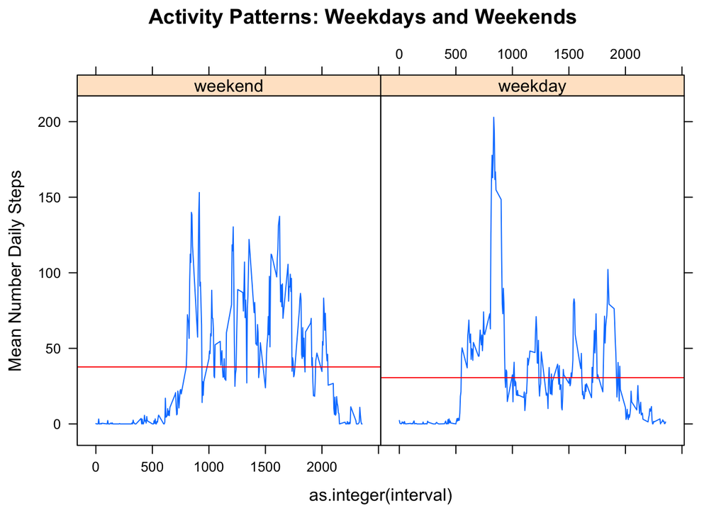

```r
d3<-data.frame(d1,WeekDay="weekday")
dat2<-rbind(d2,d3)
names(dat2)<-c("MeanSteps","interval", "Day")
dat2<-dat2[order(as.numeric(dat2$interval)),]
panel.means <- function(x, y) {
        panel.xyplot(x, y, type="l")
        panel.abline(h=mean(y),
                     col="red")
        }
scatter<-xyplot(as.numeric(MeanSteps)~as.integer(interval)|as.factor(Day),
       data=dat2,
       ylab="Mean Number Daily Steps",
       main="Activity Patterns: Weekdays and Weekends",
       panel=panel.means)
print(scatter)
```

```r
trellis.device(device="png", filename="plot1.png")
print(scatter)
dev.off()
```

The activity pattern shows distintively different patterns of activity for the weekend and the weekdays. The mean number of steps for weekday (30.63) and weekend (37.69) (the red lines on the “Activity Patterns” plot show the difference in mean activity).

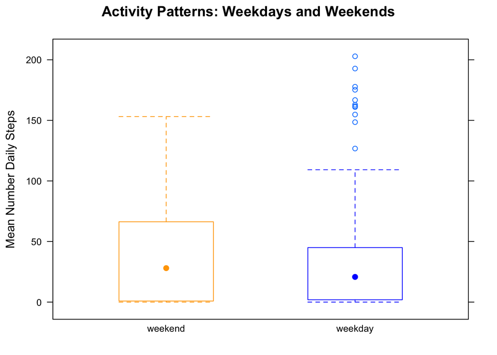

```r
bwplot(as.numeric(MeanSteps)~as.factor(Day),
       data=dat2,
       ylab="Mean Number Daily Steps",
       par.settings = list( box.umbrella=list(col= c("orange", "blue")),
                            box.dot=list(col= c("orange", "blue")),
                            box.rectangle = list(col= c("orange", "blue"))),
       main="Activity Patterns: Weekdays and Weekends")
```